# prak 1 DL, 26-9-2023

Fungsi aktivasi ReLU mengubah input yang bernilai negatif menjadi 0, sementara input yang bernilai positif tidak diubah.

Keuntungan :

ReLU sangat efisien secara komputasi.

Kekurangan :

ReLU memiliki apa yang dikenal sebagai "dying ReLU problem" - jika neuron yang menggunakan fungsi ReLU mendapatkan input negatif, maka neuron tersebut akan "mati", atau berhenti belajar

```python
# b.) ReLU (Rectified Linear Unit)

# Membuat fungsi ReLU
def ReLU(input):
    return np.maximum(input, 0)

# Contoh data input
x = np.array([-2.0, -1.0, 0.0, 1.0, 2.0])

for i in x:
    print("Angka Input : ", i, "| Output ReLU : ", ReLU(i))
```

```
Angka Input :  -2.0 | Output ReLU :  0.0
Angka Input :  -1.0 | Output ReLU :  0.0
Angka Input :  0.0 | Output ReLU :  0.0
Angka Input :  1.0 | Output ReLU :  1.0
Angka Input :  2.0 | Output ReLU :  2.0
```

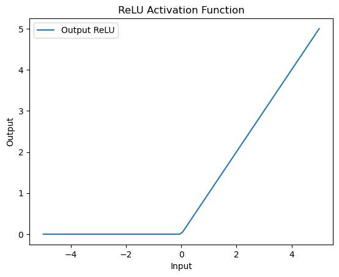

```python
# Membuat Grafik Output ReLU
# Membuat data yang akan dimasukkan ke ReLU
# Data ini memiliki jumlah sebanyak 100 dengan rentang dari -5 sampai 5
x = np.linspace(-5, 5, 100)

# Menyimpan output ReLU
output = ReLU(x)

# Membuat grafik output ReLU
plt.plot(x, output, label='Output ReLU')
plt.title('ReLU Activation Function')
plt.xlabel('Input')
plt.ylabel('Output')
plt.legend()
plt.show()
```

**c.) Tanh**

Tanh adalah alternatif lain untuk sigmoid. Output dari fungsi ini memiliki rentang lebih besar dari sigmoid yaitu berkisar antara -1 hingga 1, yang menjadikannya lebih baik dalam menangani negatif input

Keuntungan :

Sama seperti sigmoid, tetapi lebih baik menangani input negatif.

Kekurangan :

Sebesar dan sekecil apapun nilai input, Output yang dikeluarkan hanya di sekitar -1 sampai 1.

```python
# c.) Tanh

# Membuat fungsi tanh
def tanh(input):
    return np.tanh(input)

# Contoh data input
x = np.array([-2.0, -1.0, 0.0, 1.0, 2.0])

for i in x:
    print("Angka Input : ", i, "| Output Tanh : ", tanh(i))
```

```
Angka Input :  -2.0 | Output Tanh :  -0.9640275800758169
Angka Input :  -1.0 | Output Tanh :  -0.7615941559557649
Angka Input :  0.0 | Output Tanh :  0.0
Angka Input :  1.0 | Output Tanh :  0.7615941559557649
Angka Input :  2.0 | Output Tanh :  0.9640275800758169
```

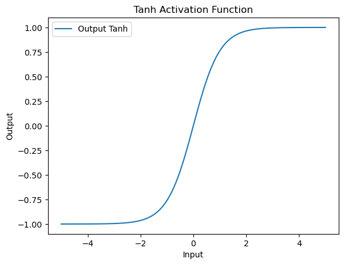

```python
# Membuat Grafik Output tanh
# Membuat data yang akan dimasukkan ke tanh
# Data ini memiliki jumlah sebanyak 100 dengan rentang dari -5 sampai 5
x = np.linspace(-5, 5, 100)

# Menyimpan output tanh
output = tanh(x)

# Membuat grafik output tanh
plt.plot(x, output, label='Output Tanh')
plt.title('Tanh Activation Function')
plt.xlabel('Input')
plt.ylabel('Output')
plt.legend()
plt.show()
```

**d.) Softmax**

Fungsi aktivasi softmax digunakan dalam lapisan output jaringan yang digunakan untuk klasifikasi multi-kelas. Ini mengubah nilai input menjadi vektor probabilitas.

Keuntungan :

Berguna untuk klasifikasi multi-kelas.

Kekurangan :

Tidak cocok untuk digunakan di hidden layers.

```python
# d.) SOFTMAX

# Membuat fungsi Softmax
def softmax(input):
    e_x = np.exp(x - np.max(input))
    return e_x / e_x.sum()

# Contoh data input
x = np.array([-2.0, -1.0, 0.0, 1.0, 2.0])

for i in x:
    print("Angka Input : ", i, "| Output Softmax : ", softmax(i))
```

```
Angka Input :  -2.0 | Output Softmax :  [0.01165623 0.03168492 0.08612854 0.23412166 0.63640865]
Angka Input :  -1.0 | Output Softmax :  [0.01165623 0.03168492 0.08612854 0.23412166 0.63640865]
Angka Input :  0.0 | Output Softmax :  [0.01165623 0.03168492 0.08612854 0.23412166 0.63640865]
Angka Input :  1.0 | Output Softmax :  [0.01165623 0.03168492 0.08612854 0.23412166 0.63640865]
Angka Input :  2.0 | Output Softmax :  [0.01165623 0.03168492 0.08612854 0.23412166 0.63640865]
```

**e.) Leaky ReLU**

Leaky ReLU adalah varian dari fungsi aktivasi ReLU yang memungkinkan sebagian kecil nilai negatif untuk tetap melewati tanpa menjadi nol mutlak. Ini membantu mengatasi masalah "neuron mati" yang bisa terjadi pada ReLU biasa.

Keuntungan :

Mengatasi masalah dying ReLU.

Kekurangan :

Hasilnya mungkin tidak stabil untuk data noise.

```python
# E.) LEAKY ReLU

# Membuat fungsi Leaky ReLU
def LeakyReLU(input):
    return np.maximum(0.01*input, input)

# Contoh data input
x = np.array([-2.0, -1.0, 0.0, 1.0, 2.0])

for i in x:
    print("Angka Input : ", i, "| Output Leaky ReLU : ", LeakyReLU(i))
```

```
Angka Input :  -2.0 | Output Leaky ReLU :  -0.02
Angka Input :  -1.0 | Output Leaky ReLU :  -0.01
Angka Input :  0.0 | Output Leaky ReLU :  0.0
Angka Input :  1.0 | Output Leaky ReLU :  1.0
Angka Input :  2.0 | Output Leaky ReLU :  2.0
```

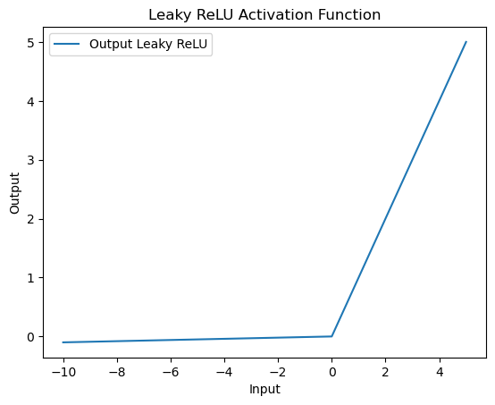

```python
# Membuat Grafik Output Leaky ReLU
# Membuat data yang akan dimasukkan ke Leaky ReLU
# Data ini memiliki jumlah sebanyak 100 dengan rentang dari -10 sampai 5
x = np.linspace(-10, 5, 100)

# Menyimpan output Leaky ReLU
output = LeakyReLU(x)

# Membuat grafik output Leaky ReLU
plt.plot(x, output, label='Output Leaky ReLU')
plt.title('Leaky ReLU Activation Function')
plt.xlabel('Input')
plt.ylabel('Output')
plt.legend()
plt.show()
```

**f.) Linear**

Fungsi aktivasi linear, yang juga dikenal sebagai identitas atau fungsi identitas, adalah salah satu jenis fungsi aktivasi yang paling sederhana.

Penggunaan :

Fungsi aktivasi linear tidak memperkenalkan unsur non-linearitas ke dalam model.

Fungsi aktivasi linear jarang digunakan dalam lapisan tersembunyi (hidden layers) dalam jaringan saraf tiruan. Hal ini karena kehadiran fungsi aktivasi linear tidak akan memberikan keuntungan tambahan dalam memodelkan data yang kompleks atau masalah yang rumit.

Fungsi aktivasi linear sering digunakan dalam lapisan output model regresi, di mana model diminta untuk memprediksi nilai numerik atau kontinu. Ini karena aktivasi linear memungkinkan model untuk menghasilkan output yang berkisar dalam seluruh rentang nilai numerik.

Macam-macam Cost Functions

Dalam konteks Neural Networks, Cost Function, juga dikenal sebagai Loss Function, adalah metrik yang digunakan untuk mengukur sejauh mana prediksi model dari nilai yang sebenarnya. Dengan kata lain, cost function memberikan ukuran "kesalahan" dalam prediksi model kita.

**1. Mean Squared Error**

Mean Squared Error adalah salah satu fungsi kerugian yang paling umum digunakan dalam masalah regresi. Fungsi ini mengukur seberapa dekat prediksi model dengan nilai sebenarnya dengan cara menghitung rata-rata kuadrat selisih antara prediksi dan nilai sebenarnya.

**Penjelasan:**

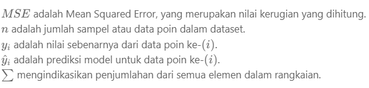

**2. Binary Crossentropy**

Fungsi loss Binary Cross-Entropy, juga dikenal sebagai Log Loss, digunakan dalam masalah klasifikasi biner.

Fungsi ini mengukur seberapa baik model klasifikasi biner memprediksi label kelas yang benar atau salah untuk setiap sampel dalam dataset.

Binary Cross-Entropy biasanya digunakan ketika Anda memiliki dua kelas yang mungkin, seperti "positif" dan "negatif."

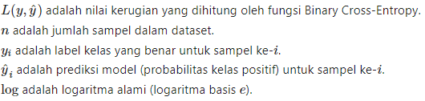

**NOTE*:**

Fungsi loss Binary Crossentropy bisa juga digunakan untuk kasus klasifikasi multi-kelas tetapi digunakan pada data yang memiliki target yang bersifat ambigu atau campuran. Contohnya warna.

```python
# contoh Data Target fungsi loss Binary Crossentropy
# Target Data Hanya mempunyai 2 kelas, 0 dan 1
y = [0, 0, 1, 1, 0, 1, 0]

# contoh Data Target Multi-Kelas yang Menggunakan fungsi loss Binary Crossentropy
y =[
    [0, 0, 0],
    [255, 0, 0],
    [20, 255, 0],]

# atau juga bisa bentuknya seperti ini
y = [
  [0, 0.1, 0.2],
  [1, 0, 0.1],
  [1, 0.8, 0],]
```

**3. Sparse Categorical Crossentropy**

Fungsi loss "sparse categorical crossentropy" adalah jenis fungsi loss yang digunakan dalam masalah klasifikasi multikelas ketika label kelas yang diberikan dalam bentuk bilangan bulat (integer) bukan dalam bentuk one-hot encoding, misalnya label kelas ada 0, 1, 2, 3, dan seterusnya.

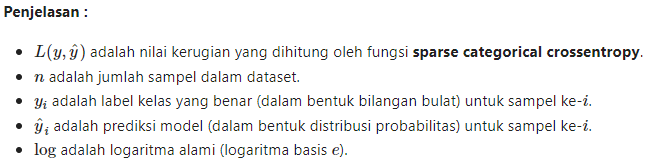

```python
# contoh Data Target yang Mneggunakan fungsi loss Sparse Categorical Crossentropy
y =[0, 0, 1, 4, 2, 3, 0,]
```

Macam-macam algoritma optimasi

a.) STOCHASTIC GRADIENT DESCENT (SGD)

b.) ADAPTIVE MOMENT ESTIMATION (Adam)

DATA TRAINING:

- Data training adalah bagian dari dataset yang digunakan untuk melatih model mesin.
- Model mesin mempelajari pola dari data training dan menyesuaikan parameter-parameternya selama proses pelatihan.

DATA TESTING:

- Data testing adalah bagian dari dataset yang terpisah dari data training dan digunakan untuk menguji kinerja model setelah pelatihan.
- Digunakan untuk mengevaluasi sejauh mana model yang dilatih mampu menggeneralisasi dan membuat prediksi yang akurat pada data yang belum pernah dilihat sebelumnya.

DATA VALIDATION:

- Data validation adalah bagian dari dataset yang digunakan selama proses pelatihan model untuk mengukur kinerja model pada setiap iterasi atau epoch.
- Ini membantu dalam memantau kemajuan pelatihan, mendeteksi overfitting (ketika model terlalu sesuai dengan data training), dan memilih model terbaik.

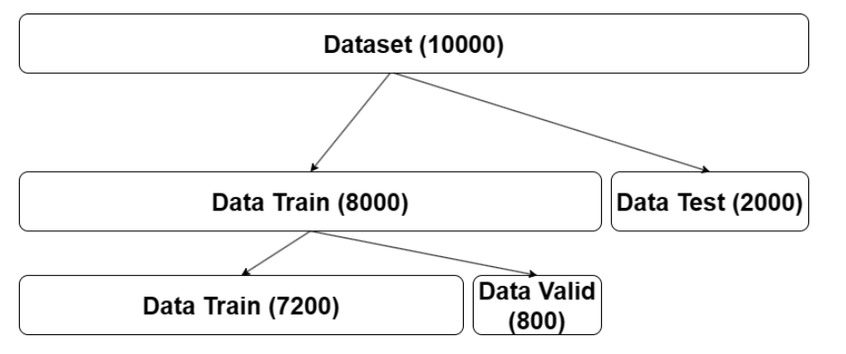

**Batch Sizes dan Epochs**

1. Batch Size
- Batch size adalah jumlah sampel data yang digunakan dalam satu iterasi pelatihan sebelum parameter model diperbarui.
- Memilih batch size yang tepat dapat memengaruhi kecepatan pelatihan dan penggunaan memori. Batch size kecil memerlukan lebih banyak iterasi tetapi dapat menghasilkan pelatihan yang lebih stabil. Batch size besar dapat mempercepat pelatihan tetapi memerlukan lebih banyak memori.

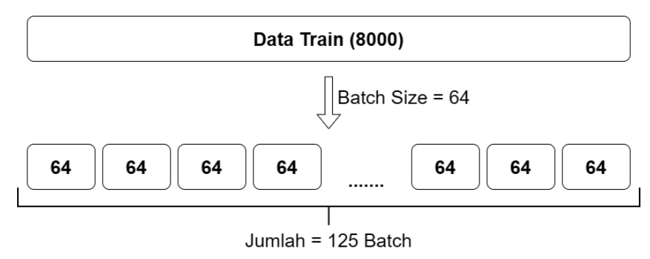

1. Epochs
- Epochs adalah jumlah iterasi pelatihan yang lengkap, di mana seluruh dataset training digunakan sekali.
- Jumlah epochs dapat bervariasi tergantung pada tingkat konvergensi model. Pelatihan biasanya berhenti jika model sudah cukup baik atau tidak lagi mengalami perbaikan yang signifikan.

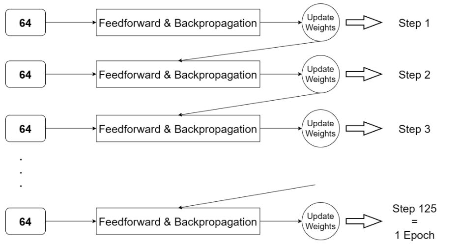

## C. Membuat Artificial Neural Network

**Persiapan Data**

Source dataset bisa di download di link ini https://drive.google.com/file/d/1O0Yjzk7scl0atmgVNWaUVcZ_eRWX49LT/view?usp=drive_link

```python
# Masukkan Data
import pandas as pd

df= pd.read_csv('C:/Semester 5/Prak Deep Learning/prak 1/praktikum_1.csv')
df
```

|  | x1 | x2 | x3 | x4 | y |
| --- | --- | --- | --- | --- | --- |
| 0 | 0.969049 | 0.811884 | 0.364106 | 0.791886 | 1.339874 |
| 1 | 0.189405 | 0.437117 | 0.105088 | 0.871999 | 0.288839 |
| 2 | 0.850152 | 0.090524 | 0.671884 | 0.809457 | 0.314485 |
| 3 | 0.944087 | 0.132889 | 0.489603 | 0.043965 | 0.940221 |
| 4 | 0.460488 | 0.903488 | 0.101475 | 0.331271 | 1.243162 |
| ... | ... | ... | ... | ... | ... |
| 9995 | 0.729730 | 0.584990 | 0.365986 | 0.680118 | 0.823030 |
| 9996 | 0.408094 | 0.964827 | 0.784377 | 0.542862 | 0.913176 |
| 9997 | 0.261231 | 0.547435 | 0.248148 | 0.855978 | 0.348508 |
| 9998 | 0.304984 | 0.907731 | 0.031752 | 0.475175 | 1.113871 |
| 9999 | 0.721289 | 0.251400 | 0.206529 | 0.433288 | 0.695005 |

10000 rows × 5 columns

File csv diatas terdiri dari 5 kolom yaitu $x1, x2, x3, x4, y$ dengan jumlah baris 10000 data.

Kolom y memiliki keterikatan dengan 4 kolom sebelumnya dengan formula

$y = x1 + x2^2 - (x3 * x4)$

**Membagi Data ke Training dan Testing**

```python
from sklearn.model_selection import train_test_split

X = df.drop('y', axis=1).values
Y = df['y'].values

x_train, x_test, y_train, y_test = train_test_split(X, Y, test_size=0.2, random_state=42)
```

**Membuat Data Validation**

```python
X_train, x_val, Y_train, y_val = train_test_split(x_train, y_train, test_size=0.2, random_state=42)
```

**Membuat Arsitektur Model**

```python
from keras.models import Sequential
from keras.layers import Dense

model = Sequential()
model.add(Dense(16, input_dim=4, activation='tanh'))
model.add(Dense(8, activation='tanh'))
model.add(Dense(4, activation='tanh'))
model.add(Dense(2, activation='tanh'))
model.add(Dense(1, activation='tanh'))
```

Perlu diperhatikan untuk layer pertama, kita perlu menspesifikasikan berapa dimensi input pertama kita. Dikarenakan input kita terdiri atas 4 komponen, $x_1$, $x_2$, $x_3$, $x_4$ maka kita perlu spesifikasikan `input_dim = 4`. Perlu diperhatikan, ini hanya perlu dilakukan sekali.

**Compile Model**

```python
model.compile(loss='mse', optimizer='adam')
model.summary()
```

```
Model: "sequential"
_________________________________________________________________
 Layer (type)                Output Shape              Param #
=================================================================
 dense (Dense)               (None, 16)                80

 dense_1 (Dense)             (None, 8)                 136

 dense_2 (Dense)             (None, 4)                 36

 dense_3 (Dense)             (None, 2)                 10

 dense_4 (Dense)             (None, 1)                 3

=================================================================
Total params: 265 (1.04 KB)
Trainable params: 265 (1.04 KB)
Non-trainable params: 0 (0.00 Byte)
_________________________________________________________________
```

Jika sudah silahkan anda `compile` dengan `loss='mse'` atau Mean Squared Error. Hal ini dikarenakan kita melakukan regresi, yang mana outputnya perlu diukur metricsnya menggunakan MSE. `.summary()` adalah fungsi yang kita pergunakan untuk melihat rangkuman bagaimana bentuk arsitektur otak yang baru saja kita buat.

**Training Model**

```python
catatan = model.fit(X_train, Y_train, validation_data=[x_val, y_val], epochs=100, batch_size=64)
```

**Plot Performa Model**

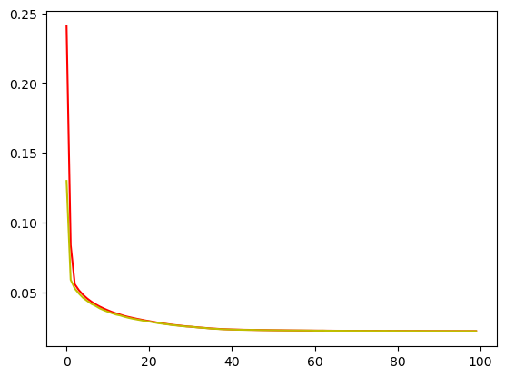

```python
import matplotlib.pyplot as plt

plt.plot(range(len(catatan.history['loss'])), catatan.history['loss'], 'r',
        range(len(catatan.history['val_loss'])), catatan.history['val_loss'], 'y')
plt.show()

#JIKA JARAK LOSS LEBIH BESAR JAUH DARIPADA VALIDATION LOSS DISEBUT 'OVERFITTING'
#JIKA JARAK LOSS LEBIH KECIL DARIPADA VALIDATION LOSS DISEBUT 'UNDERFITTING
```

**Evaluasi Model**

```python
loss = model.evaluate(x_test, y_test)
print('Loss Model = ', loss)
```

```
Loss Model =  0.027065875008702278
```

**Melakukan Prediksi**

```python
model.predict([
    [0.5, 0.4, 0.6, 0.6],
    [0.1, 0.8, 0.3, 0.7],
    [0.9, 0.10, 0.5, 0.1],
    [0.24, 0.3, 0.7, 0.11]
])
```

```
array([[0.29530573],
       [0.546166  ],
       [0.856837  ],
       [0.26705286]], dtype=float32)
```

Jika `loss` dirasa sudah cukup kecil, maka model siap kita pergunakan.

Sekarang, mari kita coba jika kita beri inputan $(x_1, x_2, x_3, x_4)$ masing-masing $(0.5, 0.4, 0.6, 0.6)$, $(0.1, 0.8, 0.3, 0.7)$, $(0.9, 0.10, 0.5, 0.1)$, $(0.24, 0.3, 0.7, 0.11)$.

Dikarenakan $y=x_1+x_2^2-(x_3*x_4)$, maka kita bisa berharap masing-masing output prediksi haruslah $0.3$, $0.53$, $0.86$, $0.252$.